# Tarea 2

# Tarea 2

## Pregunta 5

```r
library(plyr)
library(dplyr)
datos <- read.csv("INEGIConstruccion2017.csv", header=TRUE,encoding="latin1",stringsAsFactors = F)
datos <- datos[1,]
nameVars <- names(datos)
title <- gsub("Construcción..encuesta.mensual....Por.entidad.federativa...", replacement = "", x = nameVars)

pos <- grep(pattern = "Horas.trabajadas...Total.", x = title, value=FALSE)
varN <- gsub("Horas.trabajadas...Total.","", title[pos])
varN <- gsub(".Miles.de.horas.","", varN)
x1 <- datos[pos]
names(x1) <- varN

#Definiendo X1: Total de horas trabajadas (Miles de horas)
pos <- grep(pattern = "Valor.de.producción.generado.en.la.entidad...En.términos.reales...Por.tipo.de.obra...Total.", x = title, value=FALSE)
varN <- gsub("Valor.de.producción.generado.en.la.entidad...En.términos.reales...Por.tipo.de.obra...Total.","", title[pos])
varN <- gsub(".Miles.de.pesos.a.precios.de.junio.de.2012..","", varN)
x2 <- datos[pos]
names(x2) <- varN

#Definiendo X2: Valor total de producción generado en la entidad por tipo de obra ($ en términos reales)
pos <- grep(pattern = "Valor.de.producción.generado.en.la.entidad...En.términos.reales...Por.tipo.de.obra...Total.", x = title, value=FALSE)
varN <- gsub("Valor.de.producción.generado.en.la.entidad...En.términos.reales...Por.tipo.de.obra...Total.","", title[pos])
varN <- gsub(".Miles.de.pesos.a.precios.de.junio.de.2012..","", varN)
x2 <- datos[pos]
names(x2) <- varN

#Definiendo X3: Total de horas trabajadas Dependiente (Miles de horas)
pos <- grep(pattern = "Horas.trabajadas...Dependiente...Total.", x = title, value=FALSE)
varN <- gsub("Horas.trabajadas...Dependiente...Total.","", title[pos])
varN <- gsub(".Miles.de.horas.","", varN)
x3 <- datos[pos]
names(x3) <- varN

#Definiendo X4: Obreros Dependiente
pos <- grep(pattern = "Horas.trabajadas...Dependiente...Obreros.", x = title, value=FALSE)
varN <- gsub("Horas.trabajadas...Dependiente...Obreros.","", title[pos])
varN <- gsub(".Miles.de.horas.","", varN)
x4 <- datos[pos]
names(x4) <- varN

#Definiendo X5: Empleados Dependiente
pos <- grep(pattern = "Horas.trabajadas...Dependiente...Empleados.", x = title, value=FALSE)
varN <- gsub("Horas.trabajadas...Dependiente...Empleados.","", title[pos])
varN <- gsub(".Miles.de.horas.","", varN)
x5 <- datos[pos]
names(x5) <- varN

#Definiendo X6: Empleados Dependiente
pos <- grep(pattern = "Horas.trabajadas...Dependiente...Propietarios..familiares.y.otros.trabajadores.no.remunerados.", x = title, value=FALSE)
varN <- gsub("Horas.trabajadas...Dependiente...Propietarios..familiares.y.otros.trabajadores.no.remunerados.","", title[pos])
varN <- gsub(".Miles.de.horas..","", varN)
x6 <- datos[pos]
names(x6) <- varN

#Definiendo X7: Empleados Dependiente
pos <- grep(pattern = "Horas.trabajadas...No.dependiente.", x = title, value=FALSE)
varN <- gsub("Horas.trabajadas...No.dependiente.","", title[pos])
varN <- gsub(".Miles.de.horas.","", varN)
x7 <- datos[pos]
names(x7) <- varN

variables <- list(x1,x2,x3,x4,x5,x6,x7)
df <- as.data.frame(t(do.call(rbind.fill,variables)))
df <- df[1:32,]

mean <- colMeans(df,na.rm=T)
print(mean)
```

```
##           V1           V2           V3           V4           V5           V6
## 4.045648e+03 1.142586e+06 3.366957e+03 2.642589e+03 6.730238e+02 5.134369e+01
##           V7
## 6.786918e+02
```

```r
covMatrix <- cov(df, use = "complete.obs")
print(covMatrix)
```

```
##              V1           V2           V3           V4           V5
## V1   14567990.6   2232551610 9.412867e+06 7.148303e+06   2141883.71
## V2 2232551610.2 781734140931 1.730687e+09 1.234355e+09 465994225.21
## V3    9412867.2   1730687190 6.726512e+06 5.223303e+06   1420140.80
## V4    7148303.3   1234355219 5.223303e+06 4.159499e+06   1003797.58
## V5    2141883.7    465994225 1.420141e+06 1.003798e+06    394867.16
## V6     122680.2     30337746 8.306814e+04 6.000603e+04     21476.06
## V7    5155123.4    501864420 2.686356e+06 1.925001e+06    721742.90
##              V6           V7
## V1   122680.183   5155123.42
## V2 30337745.581 501864419.99
## V3    83068.142   2686355.70
## V4    60006.032   1925000.76
## V5    21476.064    721742.90
## V6     1586.046     39612.04
## V7    39612.041   2468767.72
```

```r
S <- cov(log(df), use="complete.obs")
R <- cor(log(df), use="complete.obs")
print(det(S))
```

```
## [1] 9.496053e-09
```

```r
print(prod(diag(S))*prod(eigen(R)$values))
```

```
## [1] 9.496053e-09
```

## Pregunta 1

*1. ¿Es el extremo superior siempre un outlier?*  
No, supongamos que la muestra viene de una una distribución $\mathcal{N}(0,1)$. Entonces esta muestra puede tomar valores en todo $\mathbb{R}$. Sin embargo, es posible que la muestra completa quede dentro de las barras.

*c. Supongan que los datos se distribuyen $\mathcal{N}(0,1)$. ¿Qué porcentaje de los datos esperan que caigan afuera de los whiskers?*

```r
q1 <- qnorm(0.25,mean=0,sd=1)
q3 <- qnorm(0.75,mean=0,sd=1)
qRange <- q3-q1
lW <- q1-1.5*qRange
uW <- q3+1.5*qRange
result <- pnorm(lW,mean=0,sd=1)+(1-pnorm(uW,mean=0,sd=1))
result
```

```
## [1] 0.006976603
```

*d. ¿Qué porcentaje de los datos se espera que caigan fuera de los whiskers si suponemos que los datos son normales con media 0 y varianza $\sigma^2$ con varianza desconocida $\sigma^2$?* Como la varianza escala todo el boxplot incluyendo los Whiskers, entonces el porcentaje de las observaciones que se espera que caigan fuera del boxplot es la misma que para la distribución normal estandar. Por ejemplo:

```r
x=2
for(i in 1:9) {
  x=x*x
  q1 <- qnorm(0.25,mean=0,sd=x)
  q3 <- qnorm(0.75,mean=0,sd=x)
  qRange <- q3-q1
  lW <- q1-1.5*qRange
  uW <- q3+1.5*qRange
  result <- pnorm(lW,mean=0,sd=x)+(1-pnorm(uW,mean=0,sd=x))
  print(result)
}
```

```
## [1] 0.006976603
## [1] 0.006976603
## [1] 0.006976603
## [1] 0.006976603
## [1] 0.006976603
## [1] 0.006976603
## [1] 0.006976603
## [1] 0.006976603
## [1] 0.006976603
```

## Pregunta 4

Asumiendo que el vector de medias es $\mu'=(0,0)$

- $\begin{pmatrix}5 & 4 \\4 & 5\end{pmatrix}$

```r
library(ellipse)
ma <- cbind(c(5,4),c(4,5))
e <- eigen(ma)
print(paste("Eje mayor:",sqrt(e$values[1])))
```

```
## [1] "Eje mayor: 3"
```

```r
print(paste("Eje menor:",sqrt(e$values[2])))
```

```
## [1] "Eje menor: 1"
```

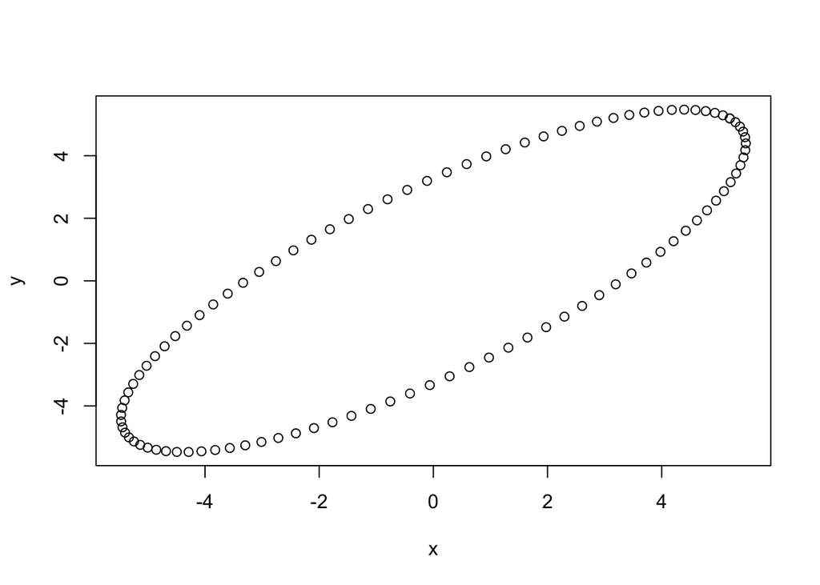

```r
plot(ellipse(ma))
```

- $\begin{pmatrix}5 & -4 \\-4 & 5\end{pmatrix}$

```r
library(ellipse)
ma <- cbind(c(5,-4),c(-4,5))
e <- eigen(ma)
print(paste("Eje mayor:",sqrt(e$values[1])))
```

```
## [1] "Eje mayor: 3"
```

```r
print(paste("Eje menor:",sqrt(e$values[2])))
```

```
## [1] "Eje menor: 1"
```

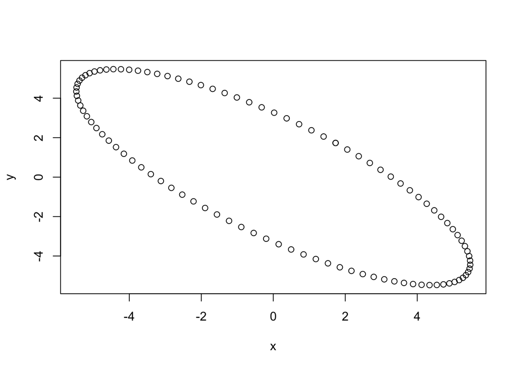

```r
plot(ellipse(ma))
```

```r
library(ellipse)
ma <- cbind(c(3,0),c(0,3))
e <- eigen(ma)
print(paste("Eje mayor:",sqrt(e$values[1])))
```

```
## [1] "Eje mayor: 1.73205080756888"
```

```r
print(paste("Eje menor:",sqrt(e$values[2])))
```

```
## [1] "Eje menor: 1.73205080756888"
```

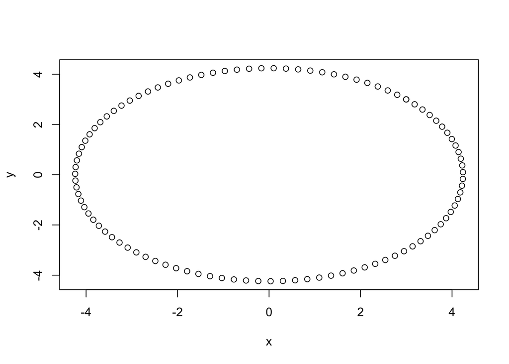

```r
plot(ellipse(ma))
```